# Introduction

# Performing the Min-Max Scaling operation and append the normalized values of the numeric features in the dataset as new columns.

The first and last 10 rows was display.

```python
# numeric features
numeric_features =['Age', 'Height', 'Weight', 'FCVC', 'NCP', 'CH2O', 'FAF', 'TUE']

# Min-Max Scaling for each numeric feature
scaler = MinMaxScaler()
scaled_values = scaler.fit_transform(dataset[numeric_features])
scaled_data = pd.DataFrame(scaled_values, columns=[f'{feat}_scaled' for feat in numeric_features])

# Append the normalized values as new columns in the dataset
dataset = pd.concat([dataset, scaled_data], axis=1)
print('First 10 rows of the normalised numeric features')
scaled_data.head(10)
```

```
First 10 rows of the normalised numeric features
```

|  | Age_scaled | Height_scaled | Weight_scaled | FCVC_scaled | NCP_scaled | CH2O_scaled | FAF_scaled | TUE_scaled |
| --- | --- | --- | --- | --- | --- | --- | --- | --- |
| 0 | 0.148936 | 0.320755 | 0.186567 | 0.5 | 0.666667 | 0.5 | 0.000000 | 0.5 |
| 1 | 0.148936 | 0.132075 | 0.126866 | 1.0 | 0.666667 | 1.0 | 1.000000 | 0.0 |
| 2 | 0.191489 | 0.660377 | 0.283582 | 0.5 | 0.666667 | 0.5 | 0.666667 | 0.5 |
| 3 | 0.276596 | 0.660377 | 0.358209 | 1.0 | 0.666667 | 0.5 | 0.666667 | 0.0 |
| 4 | 0.170213 | 0.622642 | 0.379104 | 0.5 | 0.000000 | 0.5 | 0.000000 | 0.0 |
| 5 | 0.319149 | 0.320755 | 0.104478 | 0.5 | 0.666667 | 0.5 | 0.000000 | 0.0 |
| 6 | 0.191489 | 0.094340 | 0.119403 | 1.0 | 0.666667 | 0.5 | 0.333333 | 0.0 |
| 7 | 0.170213 | 0.358491 | 0.104478 | 0.5 | 0.666667 | 0.5 | 1.000000 | 0.0 |
| 8 | 0.212766 | 0.622642 | 0.186567 | 1.0 | 0.666667 | 0.5 | 0.333333 | 0.5 |
| 9 | 0.170213 | 0.509434 | 0.216418 | 0.5 | 0.666667 | 0.5 | 0.333333 | 0.5 |

```python
# last 10 row of the scaled data
scaled_data.tail(10)
```

|  | Age_scaled | Height_scaled | Weight_scaled | FCVC_scaled | NCP_scaled | CH2O_scaled | FAF_scaled | TUE_scaled |
| --- | --- | --- | --- | --- | --- | --- | --- | --- |
| 2101 | 0.249404 | 0.336736 | 0.509097 | 1.0 | 0.666667 | 0.743535 | 0.022443 | 0.227911 |
| 2102 | 0.250333 | 0.335545 | 0.515727 | 1.0 | 0.666667 | 0.660034 | 0.015082 | 0.206553 |
| 2103 | 0.149295 | 0.517487 | 0.701743 | 1.0 | 0.666667 | 0.325306 | 0.512546 | 0.456228 |
| 2104 | 0.163455 | 0.532798 | 0.701820 | 1.0 | 0.666667 | 0.305384 | 0.503466 | 0.465728 |
| 2105 | 0.155021 | 0.522491 | 0.689073 | 1.0 | 0.666667 | 0.398134 | 0.576111 | 0.448962 |
| 2106 | 0.148443 | 0.491943 | 0.689616 | 1.0 | 0.666667 | 0.364070 | 0.558756 | 0.453124 |
| 2107 | 0.169850 | 0.563366 | 0.707037 | 1.0 | 0.666667 | 0.502565 | 0.447130 | 0.299635 |
| 2108 | 0.181362 | 0.570200 | 0.706637 | 1.0 | 0.666667 | 0.527097 | 0.471403 | 0.323144 |
| 2109 | 0.220467 | 0.546132 | 0.704079 | 1.0 | 0.666667 | 0.926170 | 0.379702 | 0.293017 |
| 2110 | 0.205632 | 0.544974 | 0.705020 | 1.0 | 0.666667 | 0.931757 | 0.342151 | 0.357069 |

# Label Encoding operation

To perform Label encoding operation I had to import the LabelEncorder libracy and also label encoding is a technique for converting category columns into numerical ones so that they may be fitted by machine learning models. The converted columns where title there orignal feature name together with "_encoded". for an instant the gender feature was a categorical feature but after been converted the new feature was titled "Gender_encoded". Below are the first and last 10 rows of the newly titled features.

```python
# Identify categorical variables
categorical_vars =['Gender', 'family_history_with_overweight', 'FAVC', 'CAEC', 'SMOKE', 'SCC', 'CALC', 'MTRANS', 'NObeyesdad']

# Label Encoding for each categorical variable
for var in categorical_vars:
    label_encoder = LabelEncoder()
    dataset[var + '_encoded'] = label_encoder.fit_transform(dataset[var])

# Insert the first-10 and last-10 rows of the new columns into the report
encoded_data_report = dataset[['Gender_encoded', 'family_history_with_overweight_encoded', 'FAVC_encoded', 'CAEC_encoded', 'SMOKE_encoded',
                               'SCC_encoded', 'CALC_encoded', 'MTRANS_encoded', 'NObeyesdad_encoded']]
encoded_data_report.head(10)
```

|  | Gender_encoded | family_history_with_overweight_encoded | FAVC_encoded | CAEC_encoded | SMOKE_encoded | SCC_encoded | CALC_encoded | MTRANS_encoded | NObeyesdad_encoded |
| --- | --- | --- | --- | --- | --- | --- | --- | --- | --- |
| 0 | 0 | 1 | 0 | 2 | 0 | 0 | 3 | 3 | 1 |
| 1 | 0 | 1 | 0 | 2 | 1 | 1 | 2 | 3 | 1 |
| 2 | 1 | 1 | 0 | 2 | 0 | 0 | 1 | 3 | 1 |
| 3 | 1 | 0 | 0 | 2 | 0 | 0 | 1 | 4 | 5 |
| 4 | 1 | 0 | 0 | 2 | 0 | 0 | 2 | 3 | 6 |
| 5 | 1 | 0 | 1 | 2 | 0 | 0 | 2 | 0 | 1 |
| 6 | 0 | 1 | 1 | 2 | 0 | 0 | 2 | 2 | 1 |
| 7 | 1 | 0 | 0 | 2 | 0 | 0 | 2 | 3 | 1 |
| 8 | 1 | 1 | 1 | 2 | 0 | 0 | 1 | 3 | 1 |
| 9 | 1 | 1 | 1 | 2 | 0 | 0 | 3 | 3 | 1 |

```python
#last 10 rows of the new features
encoded_data_report.tail(10)
```

|  | Gender_encoded | family_history_with_overweight_encoded | FAVC_encoded | CAEC_encoded | SMOKE_encoded | SCC_encoded | CALC_encoded | MTRANS_encoded | NObeyesdad_encoded |
| --- | --- | --- | --- | --- | --- | --- | --- | --- | --- |
| 2101 | 0 | 1 | 1 | 2 | 0 | 0 | 2 | 3 | 4 |
| 2102 | 0 | 1 | 1 | 2 | 0 | 0 | 2 | 3 | 4 |
| 2103 | 0 | 1 | 1 | 2 | 0 | 0 | 2 | 3 | 4 |
| 2104 | 0 | 1 | 1 | 2 | 0 | 0 | 2 | 3 | 4 |
| 2105 | 0 | 1 | 1 | 2 | 0 | 0 | 2 | 3 | 4 |
| 2106 | 0 | 1 | 1 | 2 | 0 | 0 | 2 | 3 | 4 |
| 2107 | 0 | 1 | 1 | 2 | 0 | 0 | 2 | 3 | 4 |
| 2108 | 0 | 1 | 1 | 2 | 0 | 0 | 2 | 3 | 4 |
| 2109 | 0 | 1 | 1 | 2 | 0 | 0 | 2 | 3 | 4 |
| 2110 | 0 | 1 | 1 | 2 | 0 | 0 | 2 | 3 | 4 |

# Data Visualization

Bar Chart of Obesity Categories: This visualization shows the distribution of individuals across different obesity categories.

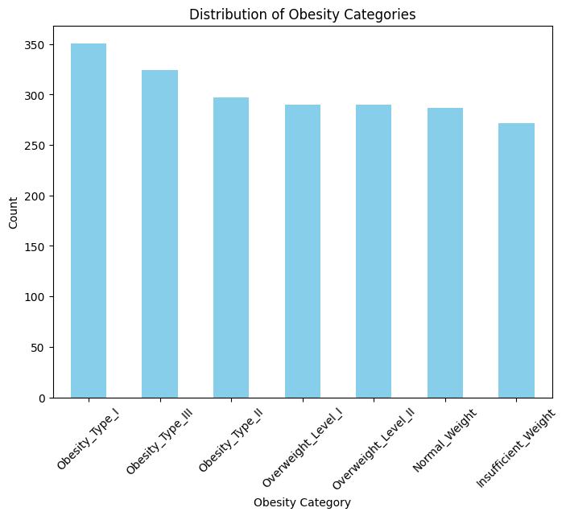

```python
# Plotting the distribution of obesity categories
plt.figure(figsize=(8, 6))
dataset['NObeyesdad'].value_counts().plot(kind='bar', color='skyblue')
plt.title('Distribution of Obesity Categories')
plt.xlabel('Obesity Category')
plt.ylabel('Count')
plt.xticks(rotation=45)
plt.show()
```

Histogram of Physical Activity Frequency (FAF): This histogram displays the distribution of physical activity frequency among individuals.

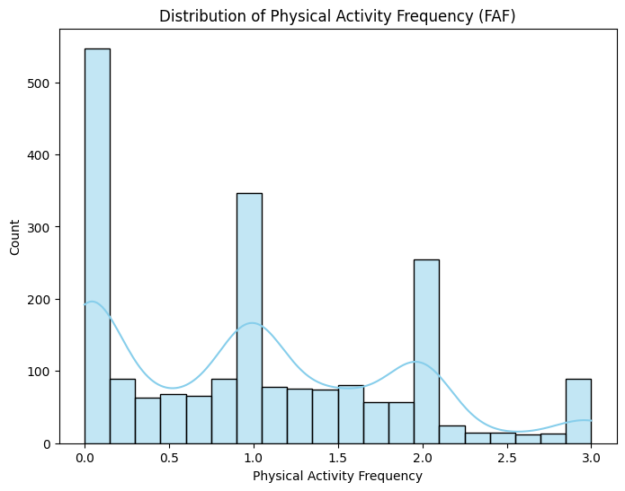

```python
# Plotting histogram of physical activity frequency (FAF)
plt.figure(figsize=(8, 6))
sns.histplot(dataset['FAF'], bins=20, kde=True, color='skyblue')
plt.title('Distribution of Physical Activity Frequency (FAF)')
plt.xlabel('Physical Activity Frequency')
plt.ylabel('Count')
plt.show()
```

Count Plot of Gender: This visualization shows the distribution of individuals by gender.

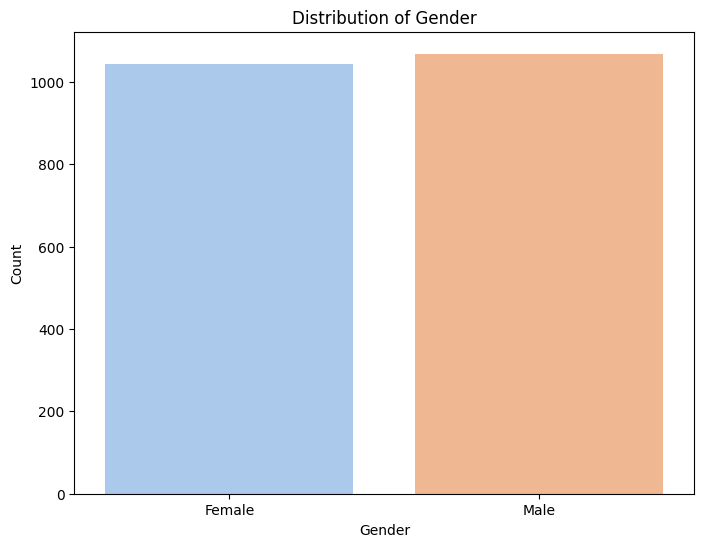

```python
# Plotting count plot of gender
plt.figure(figsize=(8, 6))
sns.countplot(x='Gender', data=dataset, palette='pastel')
plt.title('Distribution of Gender')
plt.xlabel('Gender')
plt.ylabel('Count')
plt.show()
```

Violin Plot of Calories Consumption Monitoring (SCC) by Obesity Category: This visualization shows the distribution of calories consumption monitoring across different obesity categories.

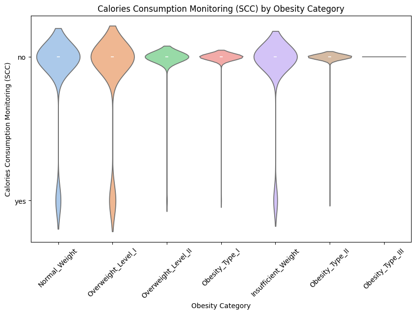

```python
# Plotting violin plot of calories consumption monitoring (SCC) by obesity category
plt.figure(figsize=(10, 6))
sns.violinplot(x='NObeyesdad', y='SCC', data=dataset, palette='pastel')
plt.title('Calories Consumption Monitoring (SCC) by Obesity Category')
plt.xlabel('Obesity Category')
plt.ylabel('Calories Consumption Monitoring (SCC)')
plt.xticks(rotation=45)
plt.show()
```

Heatmap for correlation: This visualization shows the correlation between each feature.

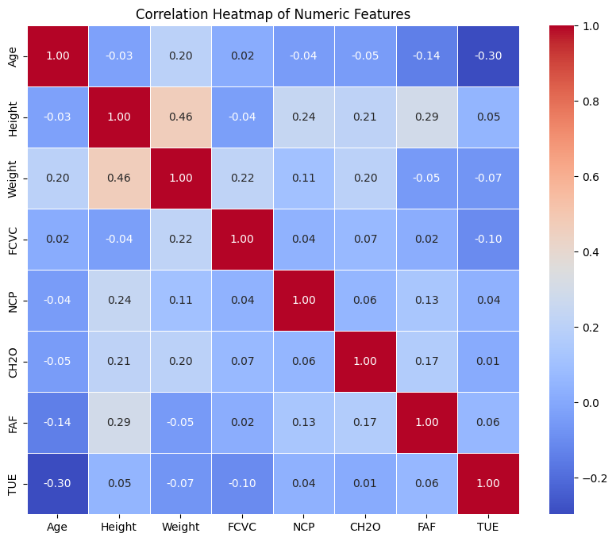

```python
# Selecting numeric features
numeric_features = ['Age', 'Height', 'Weight', 'FCVC', 'NCP', 'CH2O', 'FAF', 'TUE']

# Calculating correlation matrix
correlation_matrix = dataset[numeric_features].corr()

# Plotting correlation heatmap
plt.figure(figsize=(10, 8))
sns.heatmap(correlation_matrix, annot=True, cmap='coolwarm', fmt=".2f", linewidths=0.5)
plt.title('Correlation Heatmap of Numeric Features')
plt.show()
```

# Regression

The regression task was performed to achieve the following task: predict weight using the Height and age as the indepent variable.

1. Predicting Weight from Height and Age
2. Predicting Average Daily Water Intake (CH2O) from FAF and FCVC

```python
# Task 1: Predicting Weight
X = dataset[['Height', 'Age']]
y = dataset['Weight']

# Split data into train and test sets
X_train, X_test, y_train, y_test = train_test_split(X, y, test_size=0.3, random_state=42)

# Train the linear regression model
model1 = LinearRegression()
model1.fit(X_train, y_train)

# Predict on the test set
y_pred = model1.predict(X_test)

# Calculate Mean Squared Error (MSE) for Task 1
mse1 = mean_squared_error(y_test, y_pred)
print("Mean Squared Error for Task 1 (Predicting Weight from Height and Age):", mse1)
```

```
Mean Squared Error for Task 1 (Predicting Weight from Height and Age): 521.5699095662126
```

```python
X = dataset[['Height_scaled', 'Age_scaled']]
y = dataset['Weight_scaled']
# Split data into train and test sets
X_train, X_test, y_train, y_test = train_test_split(X, y, test_size=0.3, random_state=42)

# Train the linear regression model
model1 = LinearRegression()
model1.fit(X_train, y_train)

# Predict on the test set
y_pred = model1.predict(X_test)

# Calculate Mean Squared Error (MSE) for Task 1
mse1 = mean_squared_error(y_test, y_pred)
print("Mean Squared Error for Task 1 (Predicting Weight from Height and Age):", mse1)
```

```
Mean Squared Error for Task 1 (Predicting Weight from Height and Age): 0.029047110134006043
```

# Task 2: Predicting Average Daily Water Intake (CH2O) from FAF and FCVC

```python
# Task 2: Predicting Average Daily Water Intake (CH2O) from FAF and FCVC
X2 = dataset[['FAF', 'FCVC']]
y2 = dataset['CH2O']

# Split data into train and test sets
X2_train, X2_test, y2_train, y2_test = train_test_split(X2, y2, test_size=0.2, random_state=42)

# Train the linear regression model
model2 = LinearRegression()
model2.fit(X2_train, y2_train)

# Predict on the test set
y2_pred = model2.predict(X2_test)

# Calculate Mean Squared Error (MSE) for Task 2
mse2 = mean_squared_error(y2_test, y2_pred)
print("Mean Squared Error for Task 2 (Predicting CH2O from FAF and FCVC):", mse2)
```

```
Mean Squared Error for Task 2 (Predicting CH2O from FAF and FCVC): 0.38124015299269104
```

```python
X2 = dataset[['FAF_scaled', 'FCVC_scaled']]
y2 = dataset['CH2O_scaled']

# Split data into train and test sets
X2_train, X2_test, y2_train, y2_test = train_test_split(X2, y2, test_size=0.2, random_state=42)

# Train the linear regression model
model2 = LinearRegression()
model2.fit(X2_train, y2_train)

# Predict on the test set
y2_pred = model2.predict(X2_test)

# Calculate Mean Squared Error (MSE) for Task 2
mse2 = mean_squared_error(y2_test, y2_pred)
print("Mean Squared Error for Task 2 (Predicting CH2O from FAF and FCVC):", mse2)
```

```
Mean Squared Error for Task 2 (Predicting CH2O from FAF and FCVC): 0.09531003824817275
```

# Classification

The classification task was performed to achieve the following task:

1. Predicting Obesity status
2. Predicting Smoking Status

**Task 1**

```python
# prediction of obesity status
# Select categorical features and target variable
X = dataset[['Gender_encoded', 'family_history_with_overweight_encoded', 'FAVC_encoded', 'CAEC_encoded', 'MTRANS_encoded']]
y1 = dataset['NObeyesdad']

# Split data into train and test sets
X_train1, X_test1, y_train1, y_test1 = train_test_split(X, y1, test_size=0.3, random_state=42)

# Task 1: Predicting Obesity Status
# Train the classifier
classifier1 = RandomForestClassifier(random_state=42)
classifier1.fit(X_train1, y_train1)

# Make predictions
y_pred1 = classifier1.predict(X_test1)

# Evaluate the model
print("Classification Report for Predicting Obesity Status:")
print(classification_report(y_test1, y_pred1))
```

```
Classification Report for Predicting Obesity Status:
                     precision    recall  f1-score   support

Insufficient_Weight       0.60      0.59      0.60        86
      Normal_Weight       0.59      0.45      0.51        93
     Obesity_Type_I       0.34      0.10      0.15       102
    Obesity_Type_II       0.38      0.98      0.54        88
   Obesity_Type_III       0.63      0.99      0.77        98
 Overweight_Level_I       0.60      0.20      0.31        88
Overweight_Level_II       0.61      0.28      0.38        79

           accuracy                           0.51       634
          macro avg       0.54      0.51      0.47       634
       weighted avg       0.53      0.51      0.46       634
```

```python
# Task 2: Smoking status
# Select categorical features and target variable
X = dataset[['Gender_encoded', 'family_history_with_overweight_encoded', 'FAVC_encoded', 'CAEC_encoded', 'MTRANS_encoded']]
y2 = dataset['SMOKE']
X_train2, X_test2, y_train2, y_test2 = train_test_split(X, y2, test_size=0.3, random_state=42)

classifier2 = RandomForestClassifier(random_state=42)
classifier2.fit(X_train2, y_train2)

# Make predictions
y_pred2 = classifier2.predict(X_test2)

# Evaluate the model
print("\nClassification Report for Predicting Smoking Status:")
print(classification_report(y_test2, y_pred2))
```

```
Classification Report for Predicting Smoking Status:
              precision    recall  f1-score   support

          no       0.99      1.00      0.99       625
         yes       0.00      0.00      0.00         9

    accuracy                           0.98       634
   macro avg       0.49      0.50      0.50       634
weighted avg       0.97      0.98      0.98       634
```

# Significance of the Analysis

Obesity is a major public health issue, causing a slew of chronic diseases and imposing significant economic costs on healthcare systems throughout the world.The data and model will be used to identify important obesity risk factors and guide evidence-based interventions aimed at encouraging healthier lifestyles and lowering the prevalence of obesity-related disorders. Obesity data is critical for healthcare professionals, wellness programs, insurance companies, and public health efforts. Predictive models can help healthcare practitioners identify people who are at risk of becoming obese, allowing for early intervention and illness prevention. Wellness programs and insurance firms may customize interventions and evaluate health risks, whereas fitness facilities can design exercise regimens to specific risk profiles. Public health efforts can use findings to help shape policies and actions targeted at lowering obesity prevalence and encouraging healthier lifestyles.

# Reference

Palechor, F. M., & Manotas, A. de la H. (2019). Dataset for estimation of obesity levels based on eating habits and physical condition in individuals from Colombia, Peru and Mexico. Data in Brief, 25, 104344. https://doi.org/10.1016/j.dib.2019.104344

World Health Organization. (2024). Obesity. World Health Organization. https://www.who.int/health-topics/obesity#tab=tab_1

OpenAI.(2023).ChatGPT(Sep 25 version)[Large language model]. https://chat.openai.com/chat.